# Snabb Reference Manual

Mike Pall

Luke Gorrie

Max Rottenkolber

Andy Wingo

Diego Pino Garcia

Asumu Takikawa

Cosmin Apreutesei

Diego Pino

Nikolay Nikolaev

Katerina Barone-Adesi

Jessica Tallon

Alexander Gall

Hans Huebner

Javier Guerra

Nicola Larosa

Marcel Wiget

Pete Bristow

Adrian Perez de Castro

Adrián Pérez de Castro

Antonio Nikishaev

Domen Kožar

Alexander Altshuler

Rolf Sommerhalder

Pete Kazmier

Timo Buhrmester

Nicola ‘tekNico’ Larosa

Mikhail Nazarov

Justin Cormack

Kristian Larsson

Felix Geißler

Christian Graf

Carlos Alberto Lopez Perez

R. Matthew Emerson

Jeff Loughridge

Kacper Wysocki

Adrian Perez

Vladimir Fedin

Vincenzo Maffione

Tomas Korcak

Tim Upthegrove

Tim LaBerge

Stevan Markovic

Simon Leinen

Ryan Hartlage

Peter Cawley

Kristian Kielhofner

Jon Olsson

Jianbo Liu

Jay Fenton

James Cunningham

Hui Xiang

Gernot Nusshall

Edward Hope-Morley

Anshul Makkar

Andy Chong

Alex Kordic

Alexandr Kostrikov

Alexander Spyridakis

Version 81b83a9, Fri Aug 11 09:42:00 2017 +0000

**Note:** This reference manual is a draft. The API defined in this document is not guaranteed to be stable or complete and future versions of Snabb will introduce backwards incompatible changes. With that being said, discrepancies between this document and the actual Snabb Switch implementation are considered to be bugs. Please report them in order to help improve this document.

# Introduction

*Snabb* is an extensible, virtualized, Ethernet networking toolkit. With Snabb you can implement networking applications using the *Lua language*. Snabb includes all the tools you need to quickly realize your network designs and its really fast too! Furthermore, Snabb is extensible and encourages you to grow the ecosystem to match your requirements.

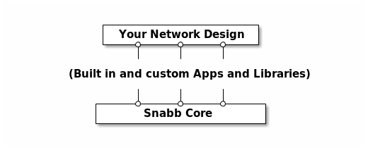

Architecture

The Snabb Core forms a runtime environment (*engine*) which executes your *design*. A design is simply a Lua script used to drive the Snabb stack, you can think of it as your top-level “main” routine.

In order to add functionality to the Snabb stack you can load modules into the Snabb engine. These can be Lua modules as well as native code objects. We differentiate between two classes of modules, namely libraries and *Apps*. Libraries are simple collections of program utilities to be used in your designs, apps or other libraries, just as you might expect. Apps, on the other hand, are code objects that implement a specific interface, which is used by the Snabb engine to organize an *App Network*.

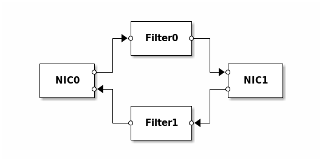

Network

Usually, a Snabb design will create a series of apps, interconnect these in a desired way using *links* and finally pass the resulting app network on to the Snabb engine. The engine’s job is to:

- Pump traffic through the app network
- Keep the app network running (e.g. restart failed apps)
- Report on the network status

# Snabb API

The core modules defined below can be loaded using Lua’s `require`. For example:

```
local config = require("core.config")

local c = config.new()
...
```

## App

An *app* is an isolated implementation of a specific networking function. For example, a switch, a router, or a packet filter.

Apps receive packets on *input ports*, perform some processing, and transmit packets on *output ports*. Each app has zero or more input and output ports. For example, a packet filter may have one input and one output port, while a packet recorder may have only an input port. Every app must implement the interface below. Methods which may be left unimplemented are marked as “optional”.

— Method **myapp:new** *arg*

*Required*. Create an instance of the app with a given argument *arg*. `Myapp:new` must return an instance of the app. The handling of *arg* is up to the app but it is encouraged to use `core.config`’s `parse_app_arg` to parse *arg*.

— Field **myapp.input**

— Field **myapp.output**

Tables of named input and output links. These tables are initialized by the engine for use in processing and are *read-only*.

— Field **myapp.appname**

Name of the app. *Read-only*.

— Field **myapp.shm**

Can be set to a specification for `core.shm.create_frame`. When set, this field will be initialized to a frame of shared memory objects by the engine.

— Field **myapp.config**

Can be set to a specification for `core.lib.parse`. When set, the specification will be used to validate the app’s arg when it is configured using `config.app`.

— Method **myapp:link**

*Optional*. Called any time the app’s links may have been changed (including on start-up). Guaranteed to be called before `pull` and `push` are called with new links.

— Method **myapp:pull**

*Optional*. Pull packets into the network.

For example: Pull packets from a network adapter into the app network by transmitting them to output ports.

— Method **myapp:push**

*Optional*. Push packets through the system.

For example: Move packets from input ports to output ports or to a network adapter.

— Method **myapp:reconfig** *arg*

*Optional*. Reconfigure the app with a new *arg*. If this method is not implemented the app instance is discarded and a new instance is created.

— Method **myapp:report**

*Optional*. Print a report of the current app status.

— Method **myapp:stop**

*Optional*. Stop the app and release associated external resources.

— Field **myapp.zone**

*Optional*. Name of the LuaJIT *profiling zone* used for this app (descriptive string). The default is the module name.

## Config (core.config)

A *config* is a description of a packet-processing network. The network is a directed graph. Nodes in the graph are *apps* that each process packets in a specific way. Each app has a set of named input and output *ports*—often called *rx* and *tx*. Edges of the graph are unidirectional *links* that carry packets from an output port to an input port.

The config is a purely passive data structure. Creating and manipulating a config object does not immediately affect operation. The config has to be activated using `engine.configure`.

— Function **config.new**

Creates and returns a new empty configuration.

— Function **config.app** *config*, *name*, *class*, *arg*

Adds an app of *class* with *arg* to the *config* where it will be assigned to *name*.

Example:

```
config.app(c, "nic", Intel82599, {pciaddr = "0000:00:00.0"})
```

— Function **config.link** *config*, *linkspec*

Add a link defined by *linkspec* to the config *config*. *Linkspec* must be a string of the format

```
app_name1.output_port->app_name2.input_port
```

where `app_name1` and `app_name2` are names of apps in *config* and `output_port` and `input_port` are valid output and input ports of the referenced apps respectively.

Example:

```
config.link(c, "nic1.tx->nic2.rx")
```

## Engine (core.app)

The *engine* executes a config by initializing apps, creating links, and driving the flow of execution. The engine also performs profiling and reporting functions. It can be reconfigured during runtime. Within Snabb Switch scripts the `core.app` module is bound to the global `engine` variable.

— Function **engine.configure** *config*

Configure the engine to use a new config *config*. You can safely call this method many times to incrementally update the running app network. The engine updates the app network as follows:

- Apps that did not exist in the old configuration are started.
- Apps that do not exist in the new configuration are stopped. (The app `stop()` method is called if defined.)
- Apps with unchanged configurations are preserved.
- Apps with changed configurations are updated by calling their `reconfig()` method. If the `reconfig()` method is not implemented then the old instance is stopped a new one started.
- Links with unchanged endpoints are preserved.

— Function **engine.main** *options*

Run the Snabb engine. *Options* is a table of key/value pairs. The following keys are recognized:

- `duration` - Duration in seconds to run the engine for (as a floating point number). If this is set you cannot supply `done`.
- `done` - A function to be called repeatedly by `engine.main` until it returns `true`. Once it returns `true` the engine will be stopped and `engine.main` will return. If this is set you cannot supply `duration`.
- `report` - A table which configures the report printed before `engine.main()` returns. The keys `showlinks` and `showapps` can be set to boolean values to force or suppress link and app reporting individually. By default `engine.main()’ will report on links but not on apps.
- `measure_latency` - By default, the `breathe()` loop is instrumented to record the latency distribution of running the app graph. This information can be processed by the `snabb top` program. Passing `measure_latency=false` in the *options* will disable this instrumentation.
- `no_report` - A boolean value. If `true` no final report will be printed.

— Function **engine.now**

Returns monotonic time in seconds as a floating point number. Suitable for timers.

— Variable **engine.busywait**

If set to true then the engine polls continuously for new packets to process. This consumes 100% CPU and makes processing latency less vulnerable to kernel scheduling behavior which can cause pauses of more than one millisecond.

Default: false

— Variable **engine.Hz**

Frequency at which to poll for new input packets. The default value is ‘false’ which means to adjust dynamically up to 100us during low traffic. The value can be overridden with a constant integer saying how many times per second to poll.

This setting is not used when engine.busywait is true.

## Link (core.link)

A *link* is a [ring buffer](http://en.wikipedia.org/wiki/Circular_buffer) used to store packets between apps. Links can be treated either like arrays—accessing their internal structure directly—or as streams of packets by using their API functions.

— Function **link.empty** *link*

Predicate used to test if a link is empty. Returns true if *link* is empty and false otherwise.

— Function **link.full** *link*

Predicate used to test if a link is full. Returns true if *link* is full and false otherwise.

— Function **link.nreadable** *link*

Returns the number of packets on *link*.

— Function **link.nwriteable** *link*

Returns the remaining number of packets that fit onto *link*.

— Function **link.receive** *link*

Returns the next available packet (and advances the read cursor) on *link*. If the link is empty an error is signaled.

— Function **link.front** *link*

Return the next available packet without advancing the read cursor on *link*. If the link is empty, `nil` is returned.

— Function **link.transmit** *link*, *packet*

Transmits *packet* onto *link*. If the link is full *packet* is dropped (and the drop counter increased).

— Function **link.stats** *link*

Returns a structure holding ring statistics for the *link*:

- `txbytes`, `rxbytes`: Counts of transferred bytes.
- `txpackets`, `rxpackets`: Counts of transferred packets.
- `txdrop`: Count of packets dropped due to ring overflow.

## Packet (core.packet)

A *packet* is an FFI object of type `struct packet` representing a network packet that is currently being processed. The packet is used to explicitly manage the life cycle of the packet. Packets are explicitly allocated and freed by using `packet.allocate` and `packet.free`. When a packet is received using `link.receive` its ownership is acquired by the calling app. The app must then ensure to either transfer the packet ownership to another app by calling `link.transmit` on the packet or free the packet using `packet.free`. Apps may only use packets they own, e.g. packets that have not been transmitted or freed. The number of allocatable packets is limited by the size of the underlying “freelist”, e.g. a pool of unused packet objects from and to which packets are allocated and freed.

— Type **struct packet**

```
struct packet {
    uint16_t length;
    uint8_t  data[packet.max_payload];
};
```

— Constant **packet.max_payload**

The maximum payload length of a packet.

— Function **packet.allocate**

Returns a new empty packet. An an error is raised if there are no packets left on the freelist. Initially the `length` of the allocated is 0, and its `data` is uninitialized garbage.

— Function **packet.free** *packet*

Frees *packet* and puts in back onto the freelist.

— Function **packet.clone** *packet*

Returns an exact copy of *packet*.

— Function **packet.resize** *packet*, *length*

Sets the payload length of *packet*, truncating or extending its payload. In the latter case the contents of the extended area at the end of the payload are filled with zeros.

— Function **packet.append** *packet*, *pointer*, *length*

Appends *length* bytes starting at *pointer* to the end of *packet*. An error is raised if there is not enough space in *packet* to accomodate *length* additional bytes.

— Function **packet.prepend** *packet*, *pointer*, *length*

Prepends *length* bytes starting at *pointer* to the front of *packet*, taking ownership of the packet and returning a new packet. An error is raised if there is not enough space in *packet* to accomodate *length* additional bytes.

— Function **packet.shiftleft** *packet*, *length*

Take ownership of *packet*, truncate it by *length* bytes from the front, and return a new packet. *Length* must be less than or equal to `length` of *packet*.

— Function **packet.shiftright** *packet*, *length*

Take ownership of *packet*, moves *packet* payload to the right by *length* bytes, growing *packet* by *length*. Returns a new packet. The sum of *length* and `length` of *packet* must be less than or equal to `packet.max_payload`.

— Function **packet.from_pointer** *pointer*, *length*

Allocate packet and fill it with *length* bytes from *pointer*.

— Function **packet.from_string** *string*

Allocate packet and fill it with the contents of *string*.

— Function **packet.clone_to_memory* *pointer* *packet*

Creates an exact copy of at memory pointed to by *pointer*. *Pointer* must point to a `packet.packet_t`.

## Memory (core.memory)

Snabb allocates special [DMA](https://en.wikipedia.org/wiki/Direct_memory_access) memory that can be accessed directly by network cards. The important characteristic of DMA memory is being located in contiguous physical memory at a stable address.

— Function **memory.dma_alloc** *bytes*, [*alignment*]

Returns a pointer to *bytes* of new DMA memory.

Optionally a specific *alignment* requirement can be provided (in bytes). The default alignment is 128.

— Function **memory.virtual_to_physical** *pointer*

Returns the physical address (`uint64_t`) the DMA memory at *pointer*.

— Variable **memory.huge_page_size**

Size of a single huge page in bytes. Read-only.

## Shared Memory (core.shm)

This module facilitates creation and management of named shared memory objects. Objects can be created using `shm.create` similar to `ffi.new`, except that separate calls to `shm.open` for the same name will each return a new mapping of the same shared memory. Different processes can share memory by mapping an object with the same name (and type). Each process can map any object any number of times.

Mappings are deleted on process termination or with an explicit `shm.unmap`. Names are unlinked from objects that are no longer needed using `shm.unlink`. Object memory is freed when the name is unlinked and all mappings have been deleted.

Names can be fully qualified or abbreviated to be within the current process. Here are examples of names and how they are resolved where `<pid>` is the PID of this process:

- Local: `foo/bar` ⇒ `/var/run/snabb/<pid>/foo/bar`
- Fully qualified: `/1234/foo/bar` ⇒ `/var/run/snabb/1234/foo/bar`

Behind the scenes the objects are backed by files on ram disk (`/var/run/snabb/<pid>`) and accessed with the equivalent of POSIX shared memory (`shm_overview(7)`). The files are automatically removed on shutdown unless the environment `SNABB_SHM_KEEP` is set. The location `/var/run/snabb` can be overridden by the environment variable `SNABB_SHM_ROOT`.

Shared memory objects are created world-readable for convenient access by diagnostic tools. You can lock this down by setting `SNABB_SHM_ROOT` to a path under a directory with appropriate permissions.

The practical limit on the number of objects that can be mapped will depend on the operating system limit for memory mappings. On Linux the default limit is 65,530 mappings:

```
$ sysctl vm.max_map_count vm.max_map_count = 65530
```

— Function **shm.create** *name*, *type*

Creates and maps a shared object of *type* into memory via a hierarchical *name*. Returns a pointer to the mapped object.

— Function **shm.open** *name*, *type*, [*readonly*]

Maps an existing shared object of *type* into memory via a hierarchical *name*. If *readonly* is non-nil the shared object is mapped in read-only mode. *Readonly* defaults to nil. Fails if the shared object does not already exist. Returns a pointer to the mapped object.

— Function **shm.alias** *new-path* *existing-path*

Create an alias (symbolic link) for an object.

— Function **shm.exists** *name*

Returns a true value if shared object by *name* exists.

— Function **shm.unmap** *pointer*

Deletes the memory mapping for *pointer*.

— Function **shm.unlink** *path*

Unlinks the subtree of objects designated by *path* from the filesystem.

— Function **shm.children** *path*

Returns an array of objects in the directory designated by *path*.

— Function **shm.register** *type*, *module*

Registers an abstract shared memory object *type* implemented by *module* in `shm.types`. *Module* must provide the following functions:

- **create** *name*, …
- **open**, *name*

and can optionally provide the function:

- **delete**, *name*

The *module*’s `type` variable must be bound to *type*. To register a new type a module might invoke `shm.register` like so:

```
type = shm.register('mytype', getfenv())
-- Now the following holds true:
--   shm.types[type] == getfenv()
```

— Variable **shm.types**

A table that maps types to modules. See `shm.register`.

— Function **shm.create_frame** *path*, *specification*

Creates and returns a shared memory frame by *specification* under *path*. A frame is a table of mapped—possibly abstract‑shared memory objects. *Specification* must be of the form:

```
{ <name> = {<module>, ...},
  ... }
```

*Module* must implement an abstract type registered with `shm.register`, and is followed by additional initialization arguments to its `create` function. Example usage:

```
local counter = require("core.counter")
-- Create counters foo/bar/{dtime,rxpackets,txpackets}.counter
local f = shm.create_frame(
   "foo/bar",
   {dtime     = {counter, C.get_unix_time()},
    rxpackets = {counter},
    txpackets = {counter}})
counter.add(f.rxpackets)
counter.read(f.dtime)
```

— Function **shm.open_frame** *path*

Opens and returns the shared memory frame under *path* for reading.

— Function **shm.delete_frame** *frame*

Deletes/unmaps a shared memory *frame*. The *frame* directory is unlinked if *frame* was created by `shm.create_frame`.

### Counter (core.counter)

Double-buffered shared memory counters. Counters are 64-bit unsigned values. Registered with `core.shm` as type `counter`.

— Function **counter.create** *name*, [*initval*]

Creates and returns a `counter` by *name*, initialized to *initval*. *Initval* defaults to 0.

— Function **counter.open** *name*

Opens and returns the counter by *name* for reading.

— Function **counter.delete** *name*

Deletes and unmaps the counter by *name*.

— Function **counter.commit**

Commits buffered counter values to public shared memory.

— Function **counter.set** *counter*, *value*

Sets *counter* to *value*.

— Function **counter.add** *counter*, [*value*]

Increments *counter* by *value*. *Value* defaults to 1.

— Function **counter.read** *counter*

Returns the value of *counter*.

### Histogram (core.histogram)

Shared memory histogram with logarithmic buckets. Registered with `core.shm` as type `histogram`.

— Function **histogram.new** *min*, *max*

Returns a new `histogram`, with buckets covering the range from *min* to *max*. The range between *min* and *max* will be divided logarithmically.

— Function **histogram.create** *name*, *min*, *max*

Creates and returns a `histogram` as in `histogram.new` by *name*. If the file exists already, it will be cleared.

— Function **histogram.open** *name*

Opens and returns `histogram` by *name* for reading.

— Method **histogram:add** *measurement*

Adds *measurement* to *histogram*.

— Method **histogram:iterate** *prev*

When used as `for count, lo, hi in histogram:iterate()`, visits all buckets in *histogram* in order from lowest to highest. *Count* is the number of samples recorded in that bucket, and *lo* and *hi* are the lower and upper bounds of the bucket. Note that *count* is an unsigned 64-bit integer; to get it as a Lua number, use `tonumber`.

If *prev* is given, it should be a snapshot of the previous version of the histogram. In that case, the *count* values will be returned as a difference between their values in *histogram* and their values in *prev*.

— Method **histogram:snapshot** [*dest*]

Copies out the contents of *histogram* into the `histogram` *dest* and returns *dest*. If *dest* is not given, the result will be a fresh `histogram`.

— Method **histogram:clear**

Clears the buckets of *histogram*.

— Method **histogram:wrap_thunk* *thunk*, *now*

Returns a closure that wraps *thunk*, measuring and recording the difference between calls to *now* before and after *thunk* into *histogram*.

## Lib (core.lib)

The `core.lib` module contains miscellaneous utilities.

— Function **lib.equal** *x*, *y*

Predicate to test if *x* and *y* are structurally similar (isomorphic).

— Function **lib.can_open** *filename*, *mode*

Predicate to test if file at *filename* can be successfully opened with *mode*.

— Function **lib.can_read** *filename*

Predicate to test if file at *filename* can be successfully opened for reading.

— Function **lib.can_write** *filename*

Predicate to test if file at *filename* can be successfully opened for writing.

— Function **lib.readcmd** *command*, *what*

Runs Unix shell *command* and returns *what* of its output. *What* must be a valid argument to `file:read`.

— Function **lib.readfile** *filename*, *what*

Reads and returns *what* from file at *filename*. *What* must be a valid argument to `file:read`.

— Function **lib.writefile** *filename*, *value*

Writes *value* to file at *filename* using `file:write`. Returns the value returned by `file:write`.

— Function **lib.readlink** *filename*

Returns the true name of symbolic link at *filename*.

— Function **lib.dirname** *filename*

Returns the `dirname(3)` of *filename*.

— Function **lib.basename** *filename*

Returns the `basename(3)` of *filename*.

— Function **lib.firstfile** *directory*

Returns the filename of the first file in *directory*.

— Function **lib.firstline** *filename*

Returns the first line of file at *filename* as a string.

— Function **lib.files_in_directory** *directory*

Returns an array of filenames in *directory*.

— Function **lib.load_string** *string*

Evaluates and returns the value of the Lua expression in *string*.

— Function **lib.load_conf** *filename*

Evaluates and returns the value of the Lua expression in file at *filename*.

— Function **lib.store_conf** *filename*, *value*

Writes *value* to file at *filename* as a Lua expression. Supports tables, strings and everything that can be readably printed using `print`.

— Function **lib.bits** *bitset*, *basevalue*

Returns a bitmask using the values of *bitset* as indexes. The keys of *bitset* are ignored (and can be used as comments).

Example:

```
bits({RESET=0,ENABLE=4}, 123) => 1<<0 | 1<<4 | 123
```

— Function **lib.bitset** *value*, *n*

Predicate to test if bit number *n* of *value* is set.

— Function **lib.bitfield** *size*, *struct*, *member*, *offset*, *nbits*, *value*

Combined accesor and setter function for bit ranges of integers in cdata structs. Sets *nbits* (number of bits) starting from *offset* to *value*. If *value* is not given the current value is returned.

*Size* may be one of 8, 16 or 32 depending on the bit size of the integer being set or read.

*Struct* must be a pointer to a cdata object and *member* must be the literal name of a member of *struct*.

Example:

```
local struct_t = ffi.typeof[[struct { uint16_t flags; }]]
-- Assuming `s' is an instance of `struct_t', set bits 4-7 to 0xF:
lib.bitfield(16, s, 'flags', 4, 4, 0xf)
-- Get the value:
lib.bitfield(16, s, 'flags', 4, 4) -- => 0xF
```

— Function **string:split** *pattern*

Returns an iterator over the string split by *pattern*. *Pattern* must be a valid argument to `string:gmatch`.

Example:

```
for word, sep in ("foo!bar!baz"):split("(!)") do
    print(word, sep)
end

> foo   !
> bar   !
> baz   nil
```

— Function **lib.hexdump** *string*

Returns hexadecimal string for bytes in *string*.

— Function **lib.hexundump** *hexstring*

Returns byte string for *hexstring*.

— Function **lib.comma_value** *n*

Returns a string for decimal number *n* with magnitudes separated by commas. Example:

```
comma_value(1000000) => "1,000,000"
```

— Function **lib.random_bytes_from_dev_urandom** *length*

Return *length* bytes of random data, as a byte array, taken from `/dev/urandom`. Suitable for cryptographic usage.

— Function **lib.random_bytes_from_math_random** *length*

Return *length* bytes of random data, as a byte array, where each byte was taken from `math.random(0, 255)`. *Not* suitable for cryptographic usage.

— Function **lib.random_bytes** *length* — Function **lib.randomseed** *seed*

Initialize Snabb’s random number generation facility. If *seed* is nil, then the Lua `math.random()` function will be seeded from `/dev/urandom`, and `lib.random_bytes` will be initialized to `lib.random_bytes_from_dev_urandom`. This is Snabb’s default mode of operation.

Sometimes it’s useful to make Snabb use deterministic random numbers. In that case, pass a seed to **lib.randomseed**; Snabb will set `lib.random_bytes` to `lib.random_bytes_from_math_random`, and also print out a message to stderr indicating that we are using lower-quality deterministic random numbers.

As part of its initialization process, Snabb will call `lib.randomseed` with the value of the `SNABB_RANDOM_SEED` environment variable (if any). Set this environment variable to enable deterministic random numbers.

— Function **lib.bounds_checked** *type*, *base*, *offset*, *size*

Returns a table that acts as a bounds checked wrapper around a C array of *type* and *size* starting at *base* plus *offset*. *Type* must be a ctype and the caller must ensure that the allocated memory region at *base*/*offset* is at least `sizeof(type)*size` bytes long.

— Function **lib.throttle** *seconds*

Return a closure that returns `true` at most once during any *seconds* (a floating point value) time interval, otherwise false.

— Function **lib.timeout** *seconds*

Returns a closure that returns `true` if *seconds* (a floating point value) have elapsed since it was created, otherwise false.

— Function **lib.waitfor** *condition*

Blocks until the function *condition* returns a true value.

— Function **lib.waitfor2** *name*, *condition*, *attempts*, *interval*

Repeatedly calls the function *condition* in *interval* (milliseconds). If *condition* returns a true value `waitfor2` returns. If *condition* does not return a true value after *attempts* `waitfor2` raises an error identified by *name*.

— Function **lib.yesno** *flag*

Returns the string `"yes"` if *flag* is a true value and `"no"` otherwise.

— Function **lib.align** *value*, *size*

Return the next integer that is a multiple of *size* starting from *value*.

— Function **lib.csum** *pointer*, *length*

Computes and returns the “IP checksum” *length* bytes starting at *pointer*.

— Function **lib.update_csum** *pointer*, *length*, *checksum*

Returns *checksum* updated by *length* bytes starting at *pointer*. The default of *checksum* is `0LL`.

— Function **lib.finish_csum** *checksum*

Returns the finalized *checksum*.

— Function **lib.malloc** *etype*

Returns a pointer to newly allocated DMA memory for *etype*.

— Function **lib.deepcopy** *object*

Returns a copy of *object*. Supports tables as well as ctypes.

— Function **lib.array_copy** *array*

Returns a copy of *array*. *Array* must not be a “sparse array”.

— Function **lib.htonl** *n*

— Function **lib.htons** *n*

Host to network byte order conversion functions for 32 and 16 bit integers *n* respectively. Unsigned.

— Function **lib.ntohl** *n*

— Function **lib.ntohs** *n*

Network to host byte order conversion functions for 32 and 16 bit integers *n* respectively. Unsigned.

— Function **lib.random_bytes** *count*

Return a fresh array of *count* random bytes. Suitable for cryptographic usage.

— Function **lib.parse** *arg*, *config*

Validates *arg* against the specification in *config*, and returns a fresh table containing the parameters in *arg* and any omitted optional parameters with their default values. Given *arg*, a table of parameters or `nil`, assert that from *config* all of the required keys are present, fill in any missing values for optional keys, and error if any unknown keys are found. *Config* has the following format:

```
config := { key = {[required=boolean], [default=value]}, ... }
```

Each key is optional unless `required` is set to a true value, and its default value defaults to `nil`.

Example:

```
lib.parse({foo=42, bar=43}, {foo={required=true}, bar={}, baz={default=44}})
  => {foo=42, bar=43, baz=44}
```

## Multiprocess operation (core.worker)

Snabb can operate as a *group* of cooperating processes. The *main* process is the initial one that you start directly. The optional *worker* processes are children spawned when the main process calls the `core.worker` module.

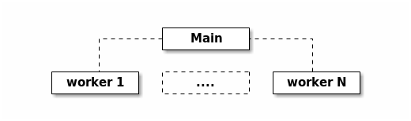

Multiprocessing

Each worker is a complete Snabb process. They can define app networks, run the engine, and do everything else that ordinary Snabb processes do. The exact behavior of each worker is determined by a Lua expression provided upon creation.

Groups of Snabb processes each have the following special properties:

- **Group termination**: Terminating the main process automatically terminates all of the workers. This works for all process termination scenarios including `kill -9`.
- **Shared DMA memory**: DMA memory pointers obtained with `memory.dma_alloc()` are usable by all processes in the group. This means that you can share DMA memory pointers between processes, for example via `shm` shared memory objects, and reference them from any process. (The memory is automatically mapped at the expected address via a `SEGV` signal handler.)
- **PCI device shutdown**: For each PCI device opened by a process within the group, bus mastering (DMA) is disabled upon termination before any DMA memory is returned to the kernel. This prevents “dangling” DMA requests from corrupting memory that has been freed and reused.

The `core.worker` API functions are available in the main process only:

— Function **worker.start** *name* *luacode*

Start a named worker process. The worker starts with a completely fresh Snabb process image (`fork()+execve()`) and then executes the string *luacode* as a Lua source code expression.

Example:

```
worker.start("myworker", [[
   print("hello world, from a Snabb worker process!")
   print("could configure and run the engine now...")
]])
```

— Function **worker.stop** *name*

Stop a named worker process. The worker is abruptly killed.

Example:

```
worker.stop("myworker")
```

— Function **worker.status**

Return a table summarizing the status of all workers. The table key is the worker name and the value is a table with `pid` and `alive` attributes.

Example:

```
for w, s in pairs(worker.status()) do
   print(("  worker %s: pid=%s alive=%s"):format(
         w, s.pid, s.alive))
end
```

Output:

```
worker w3: pid=21949 alive=true
worker w1: pid=21947 alive=true
worker w2: pid=21948 alive=true
```

## Main

Snabb designs can be run either with:

```
snabb <snabb-arg>* <design> <design-arg>*
```

or

```
#!/usr/bin/env snabb <snabb-arg>*
...
```

The *main* module provides an interface for running Snabb scripts. It exposes various operating system functions to scripts.

— Field **main.parameters**

A list of command-line arguments to the running script. Read-only.

— Function **main.exit** *status*

Cleanly exits the process with *status*.

# Basic Apps (apps.basic.basic_apps)

The module *apps.basic.basic_apps* provides apps with general functionality for use in you app networks.

## Source

The `Source` app is a synthetic packet generator. On each breath it fills each attached output link with new packets. It accepts a number as its configuration argument which is the byte size of the generated packets. By default, each packet is 60 bytes long. The packet data is initialized with zero bytes.

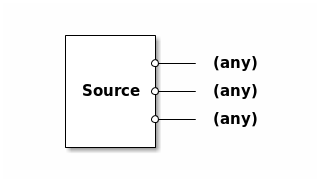

Source

## Join

The `Join` app joins together packets from N input links onto one output link. On each breath it outputs as many packets as possible from the inputs onto the output.

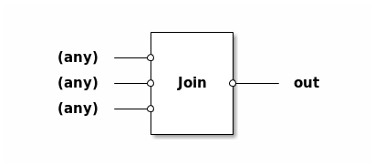

Join

## Split

The `Split` app splits packets from multiple inputs across multiple outputs. On each breath it transfers as many packets as possible from the input links to the output links.

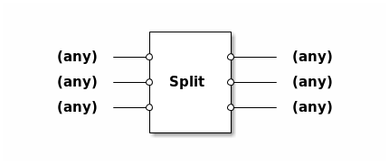

Split

## Sink

The `Sink` app receives all packets from any number of input links and discards them. This can be handy in combination with a `Source`.

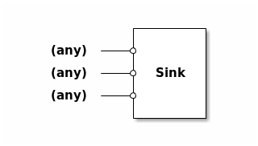

Sink

## Tee

The `Tee` app receives all packets from any number of input links and transfers each received packet to all output links. It can be used to merge and/or duplicate packet streams

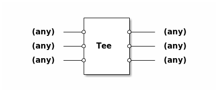

Tee

## Repeater

The `Repeater` app collects all packets received from the `input` link and repeatedly transfers the accumulated packets to the `output` link. The packets are transmitted in the order they were received.

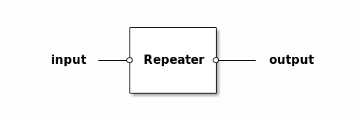

Repeater

## Truncate

The `Truncate` app sends all packets received from the `input` to the `output` link and truncates or zero pads each packet to a given length. It accepts a number as its configuration argument which is the length of the truncated or padded packets.

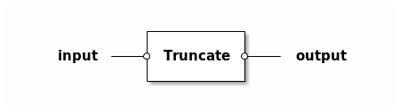

Truncate

## Sample

The `Sample` app forwards packets every *n*th packet from the `input` link to the `output` link, and drops all others packets. It accepts a number as its configuration argument which is *n*.

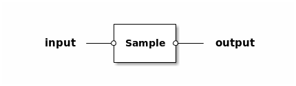

Sample

# Intel 82599 Ethernet Controller Apps

## Intel10G (apps.intel.intel_app)

The `Intel10G` drives one port of an Intel 82599 Ethernet controller. Packets taken from the `rx` port are transmitted onto the network. Packets received from the network are put on the `tx` port.

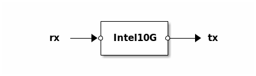

Intel10G

— Method **Intel10G.dev:get_rxstats**

Returns a table with the following keys:

- `counter_id` - Counter id
- `packets` - Number of packets received
- `dropped` - Number of packets dropped
- `bytes` - Total bytes received

— Method **Intel10G.dev:get_txstats**

Returns a table with the following keys:

- `counter_id` - Counter id
- `packets` - Number of packets sent
- `bytes` - Total bytes sent

### Configuration

The `Intel10G` app accepts a table as its configuration argument. The following keys are defined:

— Key **pciaddr**

*Required*. The PCI address of the NIC as a string.

— Key **macaddr**

*Optional*. The MAC address to use as a string. The default is a wild-card (e.g. accept all packets).

— Key **vlan**

*Optional*. A twelve bit integer (0-4095). If set, incoming packets from other VLANs are dropped and outgoing packets are tagged with a VLAN header.

— Key **vmdq**

*Optional*. Boolean, defaults to false. Enables interface virtualization. Allows to have multiple `Intel10G` apps per port. If enabled, *macaddr* must be specified.

— Key **mirror**

*Optional*. A table. If set, this app will receive copies of all selected packets on the physical port. The selection is configured by setting keys of the *mirror* table. Either *mirror.pool* or *mirror.port* may be set.

If *mirror.pool* is `true` all pools defined on this physical port are mirrored. If *mirror.pool* is an array of pool numbers then the specified pools are mirrored.

If *mirror.port* is one of “in”, “out” or “inout” all incoming and/or outgoing packets on the port are mirrored respectively. Note that this does not include internal traffic which does not enter or exit through the physical port.

— Key **rxcounter**

— Key **txcounter**

*Optional*. Four bit integers (0-15). If set, incoming/outgoing packets will be counted in the selected statistics counter respectively. Multiple apps can share a counter. To retrieve counter statistics use `Intel10G.dev:get_rxstats()` and `Intel10G.dev:get_txstats()`.

— Key **rate_limit**

*Optional*. Number. Limits the maximum Mbit/s to transmit. Default is 0 which means no limit. Only applies to outgoing traffic.

— Key **priority**

*Optional*. Floating point number. Weight for the *round-robin* algorithm used to arbitrate transmission when *rate_limit* is not set or adds up to more than the line rate of the physical port. Default is 1.0 (scaled to the geometric middle of the scale which goes from 1/128 to 128). The absolute value is not relevant, instead only the ratio between competing apps controls their respective bandwidths. Only applies to outgoing traffic.

For example, if two apps without *rate_limit* set have the same *priority*, both get the same output bandwidth. If the priorities are 3.0/1.0, the output bandwidth is split 75%/25%. Likewise, 1.0/0.333 or 1.5/0.5 yield the same result.

Note that even a low-priority app can use the whole line rate unless other (higher priority) apps are using up the available bandwidth.

### Performance

The `Intel10G` app can transmit and receive at approximately 10 Mpps per processor core.

### Hardware limits

Each physical Intel 82599 port supports the use of up to:

- 64 *pools* (virtualized `Intel10G` app instances)
- 127 MAC addresses (see the `macaddr` configuration option)
- 64 VLANs (see the `vlan` configuration option)
- 4 *mirror pools* (see the `mirror` configuration option)

## LoadGen (apps.intel.loadgen)

`LoadGen` is a *load generator* app based on the Intel 82599 Ethernet controller. It reads up to 32,000 packets from the `input` port and transmits them repeatedly onto the network. All incoming packets are dropped.

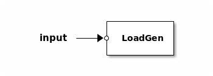

LoadGen

### Configuration

The `LoadGen` app accepts a string as its configuration argument. The given string denotes the PCI address of the NIC to use.

### Performance

The `LoadGen` app can transmit at line-rate (14 Mpps) without significant CPU usage.

# Intel i210 / i350 / 82599 Ethernet Controller apps (apps.intel_mp.intel_mp)

The `intel_mp.Intel` app provides drivers for Intel i210/i250/82599 based network cards. The driver exposes multiple receive and transmit queues that can be attached to separate instances of the app on different processes.

The links are named `input` and `output`.

## Caveats

If attaching multiple processes to a single NIC, performance appears better with `engine.busywait = false`.

The `intel_mp.Intel` app can drive an Intel 82599 NIC at 14 million pps.

## Configuration

— Key **pciaddr**

*Required*. The PCI address of the NIC as a string.

— Key **ndesc**

*Optional*. Number of DMA descriptors to use i.e. size of the DMA transmit and receive queues. Must be a multiple of 128. Default is not specified but assumed to be broadly applicable.

— Key **rxq**

*Optional*. The receive queue to attach to, numbered from 0.

— Key **txq**

*Optional*. The transmit queue to attach to, numbered from 0.

— Key **rsskey**

*Optional*. The rsskey is a 32 bit integer that seeds the hash used to distribute packets across queues. If there are multiple levels of RSS snabb devices in the packet flow making this unique will help packet distribution.

— Key **wait_for_link**

*Optional*. Boolean that indicates if `new` should block until there is a link light or not. The default is `false`.

— Key **linkup_wait**

*Optional* Number of seconds `new` waits for the device to come up. The default is 120.

— Key **linkup_wait_recheck**

*Optional* If the `linkup_wait` option is true, the number of seconds to sleep between checking the link state again. The default is 0.1 seconds.

— Key **mtu**

*Optional* The maximum packet length sent or received, excluding the trailing 4 byte CRC. The default is 9014.

— Key **master_stats**

*Optional* Boolean indicating whether to elect an arbitrary app (the master) to collect device statistics. The default is true.

— Key **run_stats**

*Optional* Boolean indicating if this app instance should collect device statistics. One per physical NIC (conflicts with `master_stats`). There is a small but detectable run time performance hit incurred. The default is false.

### RSS hashing methods

RSS will distribute packets based on as many of the fields below as are present in the packet:

- Source / Destination IP address
- Source / Destination TCP ports
- Source / Destination UDP ports

### Default RSS Queue

Packets that are not IPv4 or IPv6 will be delivered to receive queue 0.

### Hardware limits

Each chipset supports a differing number of receive / transmit queues:

- Intel82599 supports 16 receive and 16 transmit queues, 0-15
- Intel1g i350 supports 8 receive and 8 transmit queues, 0-7
- Intel1g i210 supports 4 receive and 4 transmit queues, 0-3

# Solarflare Ethernet Controller Apps

## Solarflare (apps.solarflare.solarflare)

The `Solarflare` app drives one port of a Solarflare SFN7 Ethernet controller. Multiple instances of the Solarflare app can be instantiated on the same PCI device. Packets received from the network will be dispatched between apps based on destination MAC address and VLAN. Packets taken from the `rx` port are transmitted onto the network. Packets received from the network are put on the `tx` port.

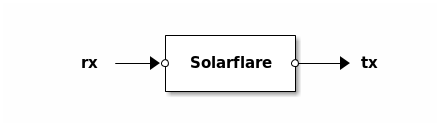

Solarflare

The `Solarflare` app requires [OpenOnload](http://www.openonload.org/) version *201502* to be installed and the `sfc` module to be loaded.

### Configuration

The `Solarflare` app accepts a table as its configuration argument. The following keys are defined:

— Key **pciaddr**

*Required*. The PCI address of the NIC as a string.

— Key **macaddr**

*Optional*. The MAC address to use as a string. The default is a wild-card (e.g. accept all packets).

— Key **vlan**

*Optional*. A twelve bit integer (0-4095). If set, incoming packets from other VLANs are dropped and outgoing packets are tagged with a VLAN header.

# RateLimiter App (apps.rate_limiter.rate_limiter)

The `RateLimiter` app implements a [Token bucket](http://en.wikipedia.org/wiki/Token_bucket) algorithm with a single bucket dropping non-conforming packets. It receives packets on the `input` port and transmits conforming packets to the `output` port.

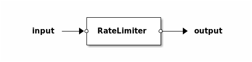

RateLimiter

— Method **RateLimiter:snapshot**

Returns throughput statistics in form of a table with the following fields:

- `rx` - Number of packets received
- `tx` - Number of packets transmitted
- `time` - Current time in nanoseconds

## Configuration

The `RateLimiter` app accepts a table as its configuration argument. The following keys are defined:

— Key **rate**

*Required*. Rate in bytes per second to which throughput should be limited.

— Key **bucket_capacity**

*Required*. Bucket capacity in bytes. Should be equal or greater than *rate*. Otherwise the effective rate may be limted.

— Key **initial_capacity**

*Optional*. Initial bucket capacity in bytes. Defaults to *bucket_capacity*.

## Performance

The `RateLimiter` app is able to process more than 20 Mpps per CPU core. Refer to its selftest for details.

# PcapFilter App (apps.packet_filter.pcap_filter)

The `PcapFilter` app receives packets on the `input` port and transmits conforming packets to the `output` port. In order to conform, a packet must match the *[pcap-filter](http://www.tcpdump.org/manpages/pcap-filter.7.html) expression* of the `PcapFilter` instance and/or belong to a *sanctioned connection*. For a connection to be sanctioned it must be tracked in a *state table* by a `PcapFilter` app using the same state table. All `PcapFilter` apps share a global namespace of *state table identifiers*. Multiple `PcapFilter` apps—e.g. for inbound and outbound traffic—can refer to the same connection by sharing a state table identifer.

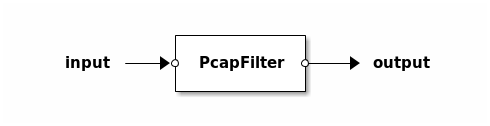

PcapFilter

## Configuration

The `PcapFilter` app accepts a table as its configuration argument. The following keys are available:

— Key **filter**

*Required*. A string containing a [pcap-filter](http://www.tcpdump.org/manpages/pcap-filter.7.html) expression.

— Key **state_table**

*Optional*. A string naming a state table. If set, packets passing any *rule* will be tracked in the specified state table and any packet that belongs to a tracked connection in the specified state table will be let pass.

## Special Counters

— Key **sessions_established**

Total number of sessions established.

# IPv4 Apps

## ARP (apps.ipv4.arp)

The `ARP` app implements the Address Resolution Protocol, allowing a Snabb network function to automatically learn the next-hop MAC address for outgoing IPv4 traffic. The `ARP` app will also respond to incoming address resolution requests from other hosts on the same network. The next-hop MAC address may also be statically configured. Finally, the Ethernet source address for all outgoing traffic will be set to the `self_mac` address configured on the `ARP` app.

All of this together means that using the `ARP` app in your network function allows you to forget about link-layer concerns, for IPv4 traffic anyway.

Topologically, the `ARP` app sits between your network function and the Ethernet interface. Its `north` link relays traffic to and from the network function; the `south` link talks instead to the Ethernet interface.

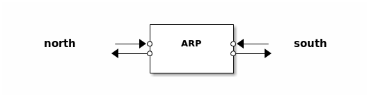

ARP

### Configuration

The `ARP` app accepts a table as its configuration argument. The following keys are defined:

— Key **self_mac**

— Key **self_ip**

*Required*. The IPv4 address of this host; used to respond to requests and when making ARP requests.

— Key **next_mac**

*Optional*. The MAC address to which to send all network traffic. This ARP app currently hsa the limitation that it assumes that all traffic will go to a single MAC address. If this address is provided as part of the configuration, no ARP request will be made; otherwise it will be determined from the *next_ip* via ARP.

— Key **self_ip**

*Optional*. The IPv4 address of the next-hop host. Required only if *next_mac* is not specified as part of the configuration.

# IPv6 Apps

## Nd_light (apps.ipv6.nd_light)

The `nd_light` app implements a small subset of IPv6 neighbor discovery (RFC4861). It has two duplex ports, `north` and `south`. The `south` port attaches to a network on which neighbor discovery (ND) must be performed. The `north` port attaches to an app that processes IPv6 packets (including full ethernet frames). Packets transmitted to the `north` port must be wrapped in full Ethernet frames (which may be empty).

The `nd_light` app replies to neighbor solicitations for which it is configured as a target and performs rudimentary address resolution for its configured *next-hop* address. If address resolution succeeds, the Ethernet headers of packets from the `north` port will be overwritten with headers containing the discovered destination address and the configured source address before they are transmitted over the `south` port. All packets from the `north` port are discarded as long as ND has not yet succeeded. Packets received from the `south` port are transmitted to the `north` port unaltered.

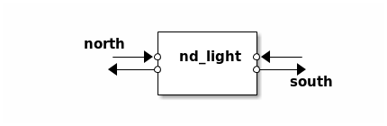

nd_light

### Configuration

The `nd_light` app accepts a table as its configuration argument. The following keys are defined:

— Key **local_mac**

*Required*. Local MAC address as a string or in binary representation.

— Key **remote_mac**

*Optional*. MAC address of **next_hop** address as a string or in binary representation. If this option is present, the `nd_light` app does not perform neighbor solicitation for the **next_hop** address and uses **remote_mac** as the MAC address associated with **next_hop**.

— Key **local_ip**

*Required*. Local IPv6 address as a string or in binary representation.

— Key **next_hop**

*Required*. IPv6 address of *next hop* as a string or in binary representation.

— Key **delay**

*Optional*. Neighbor solicitation retransmission delay in milliseconds. Default is 1,000ms.

— Key **retrans**

*Optional*. Number of neighbor solicitation retransmissions. Default is unlimited retransmissions.

— Key **quiet**

*Optional*. If set to **true**, suppress log messages about ND activity. Default is **false**.

### Special Counters

— Key **ns_checksum_errors**

Neighbor solicitation requests dropped due to invalid ICMP checksum.

— Key **ns_target_address_errors**

Neighbor solicitation requests dropped due to invalid target address.

— Key **na_duplicate_errors**

Neighbor advertisement requests dropped because next-hop is already resolved.

— Key **na_target_address_errors**

Neighbor advertisement requests dropped due to invalid target address.

— Key **nd_protocol_errors**

Neighbor discovery requests dropped due to protocol errors (invalid IPv6 hop-limit or invalid neighbor solicitation request options).

## SimpleKeyedTunnel (apps.keyed_ipv6_tunnel.tunnel)

The `SimpleKeyedTunnel` app implements “a simple L2 Ethernet over IPv6 tunnel encapsulation” as described in [Keyed IPv6 Tunnel](http://tools.ietf.org/html/draft-mkonstan-keyed-ipv6-tunnel-01). It has two duplex ports, `encapsulated` and `decapsulated`. Packets transmitted on the `decapsulated` input port will be encapsulated and put on the `encapsulated` output port. Packets transmitted on the `encapsulated` input port will be decapsulated and put on the `decapsulated` output port.

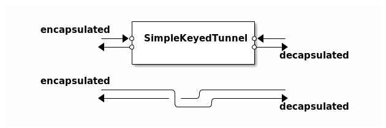

SimpleKeyedTunnel

### Configuration

The `SimpleKeyedTunnel` app accepts a table as its configuration argument. The following keys are defined:

— Key **local_address**

*Required*. Local IPv6 address as a string.

— Key **remote_address**

*Required*. Remote IPv6 address as a string.

— Key **local_cookie**

*Required*. Local cookie, 8 bytes encoded in a hexadecimal string.

— Key **remote_cookie**

*Required*. Remote cookie, 8 bytes encoded in a hexadecimal string.

— Key **local_session**

*Optional*. Unsigned integer, 32 bit. If set, the `session_id` field of the L2TPv3 header will be overwritten with this value.

— Key **hop_limit**

*Optional*. Unsigned integer. Sets the *hop limit*. Default is 64.

— Key **default_gateway_MAC**

*Optional*. Destination MAC as a string. Not required if overwritten by an app such as `nd_light`.

### Special Counters

— Key **length_errors**

Ingress packets dropped due to invalid length (packet too short).

— Key **protocol_errors**

Ingress packets dropped due to unrecognized IPv6 protocol ID.

— Key **cookie_errors**

Ingress packets dropped due to wrong cookie value.

— Key **remote_address_errors**

Ingress packets dropped due to wrong remote IPv6 endpoint address.

— Key **local_address_errors**

Ingress packets dropped due to wrong local IPv6 endpoint address.

# VhostUser App (apps.vhost.vhost_user)

The `VhostUser` app implements portions of the [Virtio](http://ozlabs.org/~rusty/virtio-spec/virtio-paper.pdf) protocol for virtual ethernet I/O interfaces. In particular, `VhostUser` supports the virtio *vring* data structure for packet I/O in shared memory (DMA) and the Linux *vhost* API for creating vrings attached to [tuntap](https://www.kernel.org/doc/Documentation/networking/tuntap.txt) devices.

With `VhostUser` SnabbSwitch can be used as a virtual ethernet interface by *QEMU virtual machines*. When connected via a UNIX socket, packets can be sent to the virtual machine by transmitting them on the `rx` port and packets sent by the virtual machine will arrive on the `tx` port.

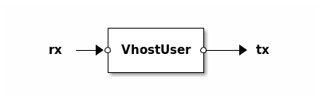

VhostUser

## Configuration

The `VhostUser` app accepts a table as its configuration argument. The following keys are defined:

— Key **socket_path**

*Optional*. A string denoting the path to the UNIX socket to connect on. Unless given all incoming packets will be dropped.

— Key **is_server**

*Optional*. Listen and accept an incoming connection on *socket_path* instead of connecting to it.

# VirtioNet App (apps.virtio_net.virtio_net)

The `VirtioNet` app implements a subset of the driver part of the [virtio-net](http://docs.oasis-open.org/virtio/virtio/v1.0/csprd04/virtio-v1.0-csprd04.html) specification. It can connect to a virtio-net device from within a QEMU virtual machine. Packets can be sent out of the virtual machine by transmitting them on the `rx` port, and packets sent to the virtual machine will arrive on the `tx` port.

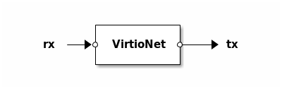

VirtioNet

## Configuration

The `VirtioNet` app accepts a table as its configuration argument. The following keys are defined:

— Key **pciaddr**

*Required*. The PCI address of the virtio-net device.

— Key **use_checksum**

*Optional*. Boolean value to enable the checksum offloading pre-calculations applied on IPv4/IPv6 TCP and UDP packets.

# PcapReader and PcapWriter Apps (apps.pcap.pcap)

The `PcapReader` and `PcapWriter` apps can be used to inject and log raw packet data into and out of the app network using the [Libpcap File Format](http://wiki.wireshark.org/Development/LibpcapFileFormat/). `PcapReader`reads raw packets from a PCAP file and transmits them on its `output` port while `PcapWriter` writes packets received on its `input` port to a PCAP file.

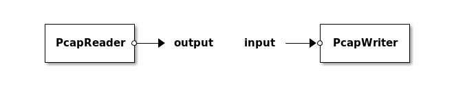

PcapReader

## Configuration

Both `PcapReader` and `PcapWriter` expect a filename string as their configuration arguments to read from and write to respectively. `PcapWriter` will alternatively accept an array as its configuration argument, with the first element being the filename and the second element being a *mode* argument to `io.open`.

# RawSocket App (apps.socket.raw)

The `RawSocket` app is a bridge between Linux network interfaces (`eth0`, `lo`, etc.) and a Snabb app network. Packets taken from the `rx` port are transmitted over the selected interface. Packets received on the interface are put on the `tx` port.

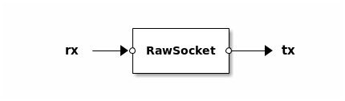

RawSocket

## Configuration

The `RawSocket` app accepts a string as its configuration argument. The string denotes the interface to bridge to.

# UnixSocket App (apps.socket.unix)

The `UnixSocket` app provides I/O for a named Unix socket.

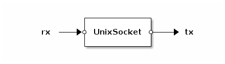

UnixSocket

## Configuration

The `UnixSocket` app takes a string argument which denotes the Unix socket file name to open, or a table with the fields:

- `filename` - the Unix socket file name to open.
- `listen` - if `true`, listen for incoming connections on the socket rather than connecting to the socket in client mode.
- `mode` - can be “stream” or “packet” (the default is “stream”): the difference is that in packet mode, the packets are not split or merged (in both modes packets arrive in order).

**NOTE**: The socket is not opened until the first call to push() or pull(). If connection is lost, the socket will be re-opened on the next call to push() or pull().

# Tap app (apps.tap.tap)

The `Tap` app is used to interact with a Linux [tap](https://www.kernel.org/doc/Documentation/networking/tuntap.txt) device. Packets transmitted on the `input` port will be sent over the tap device, and packets that arrive on the tap device can be received on the `output` port.

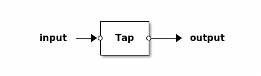

Tap

## Configuration

This app accepts either a single string or a table as its configuration argument. A single string is equivalent to the default configuration with the `name` attribute set to the string.

— Key **name**

*Required*. The name of the tap device.

If the device does not exist yet, which is inferred from the absence of the directory `/sys/class/net/`**name**, it will be created by the app and removed when the process terminates. Such a device is called *ephemeral* and its operational state is set to *up* after creation.

If the device already exists, it is called *persistent*. The app can attach to a persistent tap device and detaches from it when it terminates. The operational state is not changed. By default, the MTU is also not changed by the app, see the **mtu_set** option below.

One manner in which a persistent tap device can be created is by using the `ip` tool

```
ip tuntap add Tap345 mode tap
ip link set up dev Tap345
ip link set address 02:01:02:03:04:08 dev Tap0
```

— Key **mtu**

*Optional*. The L2 MTU of the device. The default is 1514.

By definition, the L2 MTU includes the size of the L2 header, e.g. 14 bytes in case of Ethernet without VLANs. However, the Linux `ioctl` methods only expose the L3 (IP) MTU, which does not include the L2 header. The following configuration options are used to correct this discrepancy.

— Key **mtu_fixup**

*Optional*. A boolean that indicates whether the **mtu** option should be corrected for the difference between the L2 and L3 MTU. The default is *true*.

— Key **mtu_offset**

*Optional*. The value by which the **mtu** is reduced when **mtu_fixup** is set to *true*. The default is 14.

The resulting MTU is called the *effective* MTU.

— Key **mtu_set**

*Optional*. Either *nil* or a boolean that indicates whether the MTU of the tap device should be set or checked. If **mtu_set** is *true*, the MTU of the tap device is set to the effective MTU. If **mtu_set** is false, the effective MTU is compared with the current value of the MTU of the tap device and an error is raised in case of a mismatch.

If **mtu_set** is *nil*, the MTU is set or checked if the tap device is ephemeral or persistent, respectively. The rationale is that if the device is persistent, the entity that created the device is responsible for the configuration and might not expect or react well to a change of the MTU.

# VLAN Apps

There are three VLAN related apps, `Tagger`, `Untagger` and `VlanMux`. The `Tagger` and `Untagger` apps add or remove a VLAN tag whereas the `VlanMux` app can multiplex and demultiplex packets to different output ports based on tag.

## Tagger (apps.vlan.vlan)

The `Tagger` app adds a VLAN tag, with the configured value and encapsulation, to packets received on its `input` port and transmits them on its `output` port.

### Configuration

— Key **encapsulation**

*Optional*. The Ethertype to use as encapsulation for the VLAN. Permitted values are the strings *“dot1q”* and *“dot1ad”* or a number to select an arbitrary Ethertype. *“dot1q”* and *“dot1ad”* correspond to the Ethertypes 0x8100 and 0x88a8, respectively, according to the IEEE standards 802.1Q and 802.1ad.

If a number is given, it is truncated to 16 bits. This feature is intended to allow interoperation with vendors that do not use one of the standard encapsulations (a prominent example being the value 0x9100, which can still be found in practice for double-tagging instead of 0x88a8).

The default is *“dot1q”*.

— Key **tag**

*Required*. VLAN tag to add or remove from the packet. The value must be a number in the range 1-4094 (inclusive).

## Untagger (apps.vlan.vlan)

The `Untagger` app checks packets received on its `input` port for a VLAN tag, removes it if it matches with the configured VLAN tag and transmits them on its `output` port. Packets with other VLAN tags than the configured tag are dropped.

### Configuration

— Key **encapsulation**

*Optional*. See above.

— Key **tag**

*Required*. VLAN tag to add or remove from the packet. The value must be a number in the range 1-4094 (inclusive).

## VlanMux (apps.vlan.vlan)

Despite the name, the `VlanMux` app can act both as a multiplexer, i.e. receive packets from multiple different input ports, add a VLAN tag and transmit them out onto one, as well as receiving packets from its `trunk` port and demultiplex it over many output ports based on the VLAN tag of the received packet. It supports the notion of a “native VLAN” by mapping untagged frames on the trunk port to a dedicated output port.

A packet received on its `trunk` input port must either be untagged or tagged with the encapsulation as specified with the **encapsulation** configuration option. Otherwise, the packet is dropped.

If the Ethernet frame is tagged, the VLAN ID is extracted and the packet is transmitted on the port named `vlan<vid>`, where `<vid>` is the decimal representation of the VLAN ID. If no such port exists, the packet is dropped.

If the Ethernet frame is untagged, it is transmitted on the port named `native` or dropped if no such port exists.

A packet received on a port named `vlan<vid>` is tagged with the VLAN ID `<vid>` according to the configured encapsulation and transmitted on the trunk port.

A packet received on the port named `native` is transmitted as is on the trunk port.

### Configuration

— Key **encapsulation**

*Optional*. See above.

# Bridge Apps

A `bridge` app implements a basic Ethernet bridge with split-horizon semantics. It has an arbitrary number of ports. For each input port there must exist an output port with the same name. Each port name is a member of at most one *split-horizon group*. If it is not a member of a split-horizon group, the port is also called a *free port*. Packets arriving on a free input port may be forwarded to all other output ports. Packets arriving on an input port that belongs to a split-horizon group are never forwarded to any output port belonging to the same split-horizon group. There are two `bridge` implementations available: `apps.bridge.flooding` and apps.bridge.learning`.

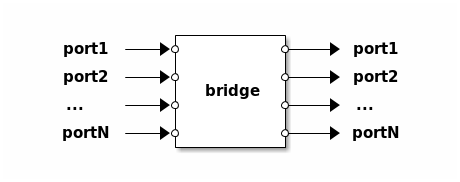

bridge

## Configuration

A `bridge` app accepts a table as its configuration argument. The following keys are defined:

— Key **ports**

*Optional*. An array of free port names. The default is no free ports.

— Key **split_horizon_groups**

*Optional*. A table mapping split-horizon groups to arrays of port names. The default is no split-horizon groups.

— Key **config**

*Optional*. The configuration of the actual bridge implementation.

## Flooding bridge (apps.bridge.flooding)

The flooding `bridge` app implements the simplest possible bridge, which floods a packet arriving on an input port to all output ports within its scope according to the split-horizon topology.

### Configuration

The flooding `bridge` app ignores the *config* key of its configuration.

## Learning bridge (apps.bridge.learning)

The learning `bridge` app implements a *learning bridge* using a custom hash table to store the set of MAC source addresses of packets arriving on each input port. When a packet is received it is forwarded to all output ports whose corresponding input ports match the packet’s destination MAC address. When no input port matches, the packet is flooded to all output ports. Multicast MAC addresses are always flooded to all output ports associated with the input port. The scoping rules according to the split-horizon topology apply unchanged.

### Configuration

The learning `bridge` app accepts a table as the value of the *config* key of its configuration. The following keys are defined:

— Key **mac_table**

*Optional*. This is a table that defines the characteristics of the MAC table. The following keys are defined

— Key **size**

*Optional*. The number of MAC addresses to be stored in the table. Default is 256. The size of the table is increased automatically if this limit is reached or if an overflow in one of the hash buckets occurs. This value is capped by **resize_max**.

— Key **timeout**

*Optional*. Timeout for learned MAC addresses in seconds. Default is 60.

— Key **verbose**

*Optional*. A boolean value. If true, statistics about table usage is logged during each timeout interval. Default is `false`.

— Key **copy_on_resize**

*Optional*. A boolean value. If true, the contents of the table is copied to the newly allocated table after a resize operation. Default is `true`.

— Key **resize_max**

*Optional*. An upper bound for the size of the table. Default is 65536.

# IPFIX and NetFlow apps

## IPFIX (apps.ipfix.ipfix)

The `IPFIX` app implements an RFC 7011 IPFIX “meter” and “exporter” that records the flows present in incoming traffic and sends exported UDP packets describing those flows to an external collector (not included). The exporter can produce output in either the standard RFC 7011 IPFIX format, or the older NetFlow v9 format from RFC 3954.

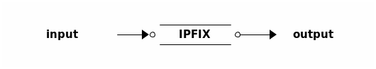

IPFIX

See the `snabb ipfix probe` command-line interface for a program built using this app.

### Configuration

The `IPFIX` app accepts a table as its configuration argument. The following keys are defined:

— Key **idle_timeout**

*Optional*. Number of seconds after which a flow should be considered idle and available for expiry. The default is 300 seconds.

— Key **active_timeout**

*Optional*. Period at which an active, non-idle flow should produce export records. The default is 120 seconds.

— Key **cache_size**

*Optional*. Initial size of flow tables, in terms of number of flows. The default is 20000.

— Key **template_refresh_interval**

*Optional*. Period at which to send template records over UDP. The default is 600 seconds.

— Key **ipfix_version**

*Optional*. Version of IPFIX to export. 9 indicates legacy NetFlow v9; 10 indicates RFC 7011 IPFIX. The default is 10.

— Key **mtu**

*Optional*. MTU for exported UDP packets. The default is 512.

— Key **observation_domain**

*Optional*. Observation domain tag to attach to all exported packets. The default is 256.

— Key **exporter_ip**

*Required*, sadly. The IPv4 address from which to send exported UDP packets.

— Key **collector_ip**

*Required*. The IPv4 address to which to send exported UDP packets.

— Key **collector_port**

*Required*. The port on which the collector is listening for UDP packets.

— Key **templates**

*Optional*. The templates for flows being collected. See the source code for more information.

### To-do list

Some ideas for things to hack on are below.

#### Limit the number of flows

As it is, if an attacker can create millions of flows, then our flow set will expand to match (and never shrink). Perhaps we should cap the total size of the flow table.

#### Look up multiple keys in parallel

For large ctables, we can only do 7 or 8 million lookups per second if we look up one key after another. However if we do lookups in parallel, then we can get 15 million or so, which would allow us to reach 10Gbps line rate on 64-byte packets.

#### YANG schema to define IPFIX app configuration

We should try to model the configuration of the IPFIX app with a YANG schema. See RFC 6728 for some inspiration.

#### Use special-purpose internal links

The links that we use as internal buffers between parts of the IPFIX app have some overhead as they have to update counters. Perhaps we should use a special-purpose data structure.

#### Use a monotonic timer

Currently internal flow start and end times use UNIX time. This isn’t great for timers, but it does match what’s specified in RFC 7011. Could we switch to monotonic time?

#### Allow export to IPv6 collectors

We can collect IPv6 flows of course, but we only export to collectors over IPv4 for the moment.

#### Allow packets to count towards multiple templates

Right now, routing a packet towards a flow set means no other flow set can measure that packet. Perhaps this should change.

# IPsec Apps

## AES128gcm (apps.ipsec.esp)

The `AES128gcm` implements ESP in transport mode using the AES-GCM-128 cipher. It encrypts packets received on its `decapsulated` port and transmits them on its `encapsulated` port, and vice-versa. Packets arriving on the `decapsulated` port must have an IPv6 header, and packets arriving on the `encapsulated` port must have an IPv6 header followed by an ESP header, otherwise they will be discarded.

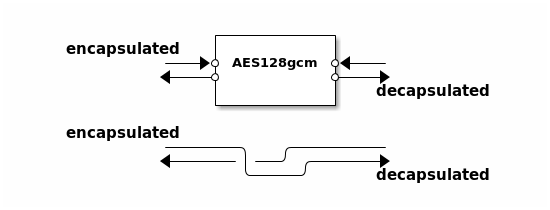

AES128gcm

References:

- `lib.ipsec.esp`

### Configuration

The `AES128gcm` app accepts a table as its configuration argument. The following keys are defined:

— Key **spi**

*Required*. A 32 bit integer denoting the “Security Parameters Index” as specified in RFC 4303.

— Key **transmit_key**

*Required*. Hexadecimal string of 32 digits (two digits for each byte) that denotes a 128-bit AES key as specified in RFC 4106 used for the encryption of outgoing packets.

— Key **transmit_salt**

*Required*. Hexadecimal string of eight digits (two digits for each byte) that denotes four bytes of salt as specified in RFC 4106 used for the encryption of outgoing packets.

— Key **receive_key**

*Required*. Hexadecimal string of 32 digits (two digits for each byte) that denotes a 128-bit AES key as specified in RFC 4106 used for the decryption of incoming packets.

— Key **receive_salt**

*Required*. Hexadecimal string of eight digits (two digits for each byte) that denotes four bytes of salt as specified in RFC 4106 used for the decryption of incoming packets.

— Key **receive_window**

*Optional*. Minimum width of the window in which out of order packets are accepted as specified in RFC 4303. The default is 128.

— Key **resync_threshold**

*Optional*. Number of consecutive packets allowed to fail decapsulation before attempting “Re-synchronization” as specified in RFC 4303. The default is 1024.

— Key **resync_attempts**

*Optional*. Number of attempts to re-synchronize a packet that triggered “Re-synchronization” as specified in RFC 4303. The default is 8.

— Key **auditing**

*Optional.* A boolean value indicating whether to enable or disable “Auditing” as specified in RFC 4303. The default is `nil` (no auditing).

# Test Apps

## Match (apps.test.match)

The `Match` app compares packets received on its input port `rx` with those received on the reference input port `comparator`, and reports mismatches as well as packets from `comparator` that were not matched.

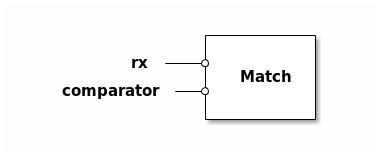

Match

— Method **Match:errors**

Returns the recorded errors as an array of strings.

### Configuration

The `Match` app accepts a table as its configuration argument. The following keys are defined:

— Key **fuzzy**

*Optional.* If this key is `true` packets from `rx` that do not match the next packet from `comparator` are ignored. The default is `false`.

— Key **modest**

*Optional.* If this key is `true` unmatched packets from `comparator` are ignored if at least one packet from ´rx´ was successfully matched. The default is `false`.

## Synth (apps.test.synth)

The `Synth` app generates synthetic packets with Ethernet headers and alternating payload sizes. On each breath it fills each attached output link with new packets.

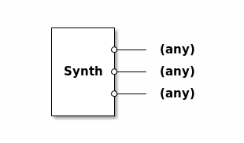

Synth

### Configuration

The `Synth` app accepts a table as its configuration argument. The following keys are defined:

— Key **src**

— Key **dst**

Source and destination MAC addresses in human readable from. The default is `"00:00:00:00:00:00"`.

— Key **sizes**

An array of numbers designating the packet payload sizes. The default is `{64}`.

# SnabbWall Apps

## L7Spy (apps.wall.l7spy)

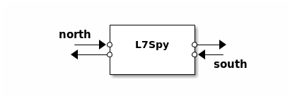

L7Spy

The `L7Spy` app is a Snabb app that scans packets passing through it using an instance of the `Scanner` class. The scanner instance may be shared among several `L7Spy` instances or with a `L7Fw` app for filtering.

— Method **L7Spy:new** *config*

Construct a new `L7Spy` app instance based on a given configuration table. The table may contain the following key:

- `scanner` (optional): Either a string identifying the kind of scanner to construct (currently only `"ndpi"` is accepted) or an existing scanner instance.

## Filter (apps.wall.filter)

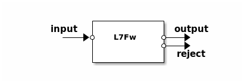

L7Fw

The `L7Fw` app implements a stateful firewall by querying the scanner state collected by a `L7Spy` app. It then filters packets based on a given set of rules.

— Method **L7Fw:new** *config*

Construct a new `L7Fw` app instance based on a given configuration table. The table may contain the following keys:

- `scanner`: A `Scanner` instance shared with an `L7Spy` instance. The metadata in this scanner is used for packet filtering.
- `rules`: A table mapping protocol names (as strings) to firewall actions. The accepted actions are `"accept"`, `"reject"`, `"drop"`, or a pfmatch expression. The pfmatch expression may use the variable `flow_count` (as an arithmetic expression) to refer to the number of packets in a given protocol flow, and may call the `accept`, `reject`, or `drop` methods.
- `local_ipv4` (optional): An IPv4 address that identifies the host running the firewall. This is used as the source address in ICMPv4 or TCP reject responses.
- `local_ipv6` (optional): An IPv6 address that identifies the host running the firewall. This is used as the source address in ICMPv6 or TCP reject responses.
- `local_macaddr` (optional): A MAC address that identifies the host running the firewall. This is used for the source address in ethernet frames for reject responses.
- `logging` (optional): A log level parameter that can be set to “on” or “off”. When set to “on”, it will report dropped/rejected packets to the system log.

## Scanner (apps.wall.scanner)

`Scanner` objects are responsible for:

- Identifying traffic flows.
- Analyzing the contents of packet to determine which application they belong to.
- Keeping enough state to be able to enumerate the identified traffic flows, and identify the application they belong to.

The class is not meant to be instantiated directly, but to be used as the basis for concrete implementations (e.g. `NdpiScanner`). It provides one function that subclasses can use:

- Method **Scanner:extract_packet_info** *packet*

Extracts fields from the headers of an IPv4 or IPv6 *packet*. The returned values are:

1. A *key* object (more on this below) which uniquely identifies a traffic flow.
2. The *offset* to the packet payload content.
3. The *source_address* of the packet, as an array of bytes.
4. The *source_port*, for UDP and TCP packets.
5. The *destination_address* of the packet, as an array of bytes.
6. The *destination_port*, for UDP and TCP packets.

Key objects contain some of the returned information in a compact FFI representation, and can be used as an aid to uniquely identify a flow of packets. The provide the following attributes:

- `:eth_type()`: Method which returns the type of the Ethernet frame payload, either `ETH_TYPE_IPv4` or `ETH_TYPE_IPv6`.
- `:hash()`: Method which returns an integer calculated by hashing all the other values in the key object.
- `.vlan_id`: VLAN identifier. Zero for no VLAN tags.
- `.ip_proto`: The IP protocol.
- `.lo_addr` and `.hi_addr`: IP addresses (either v4 or v6).
- `.lo_port` and `.hi_port`: For TCP and UDP, the ports as big-endian (network) integers.

This method can be very useful to implement scanners using backends which do not implement their own flow classification.